# designit: a flexible engine to generate experiment layouts

Juliane Siebourg-Polster, Iakov Davydov, Guido Steiner, Balazs Banfai

# Introduction

Examples in this vignette are used were used in our presentation.

It uses a subset of the `longitudinal_subject_samples` dataset.

```r
data("longitudinal_subject_samples")

dat <- longitudinal_subject_samples |>
  filter(Group %in% 1:5, Week %in% c(1, 4)) |>
  select(SampleID, SubjectID, Group, Sex, Week)

# for simplicity: remove two subjects that don't have both visits
dat <- dat |>
  filter(SubjectID %in%
    (dat |> count(SubjectID) |> filter(n == 2) |> pull(SubjectID)))


subject_data <- dat |>
  select(SubjectID, Group, Sex) |>
  unique()
```

## Batch effects matter

Here’s an example of plate effect. Here both top and bottom rows of the plate are used as controls.

This is the experiment design:

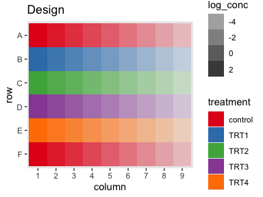

These are the readouts:

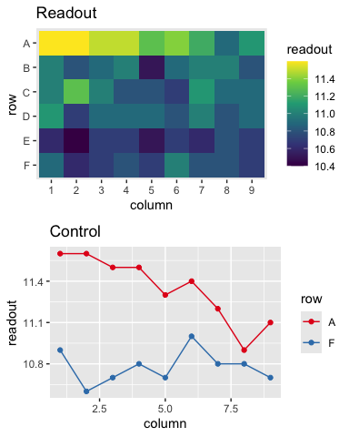

Due to the plate effect, the control rows are affected differently. It is virtually impossible to normalize readouts in a meaningful way.

## Go fully random?

- Could it be sufficient to randomly distribute samples across batches?
- Not necessarily!
  - Often sample sizes are too small to avoid grouping by change
  - Experimental constraints might not allow for a fully random layout

Gone wrong: Random distribution of 31 grouped subjects into 3 batches turns out unbalanced:

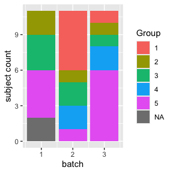

“**Block** what you can and **randomize** what you cannot.” (G. Box, 1978)

## designit

To **avoid batch or gradient effects** in complex experiments, `designit` is an R package that offers flexible ways to **allocate a given set of samples to experiment layouts**. It’s strength is that it implements a very general framework that can easily be customized and extended to fit specific constrained layouts.

- Data structure: `BatchContainer` class
  - R6 object storing:
    - Experiment dimensions (cages, plates…)
    - Sample annotation
    - Scoring functions for sample distribution
- Main function: `optimize_design()`
  - Optimizes the layout with user defined
    - Scores for sample distribution
    - Optimization protocols
    - Sample shuffling functions
  - Returns improved design and optimization trace

# Sample Batching

## Setup

- Assign 31 samples to 3 equally sized batches
- Balance by:
  - treatment group (higher priority)
  - sex (lower priority)

```r
bc <- BatchContainer$new(
  dimensions = list("batch" = 3, "location" = 11)
) |>
  assign_random(subject_data)
```

**Batch composition before optimization**

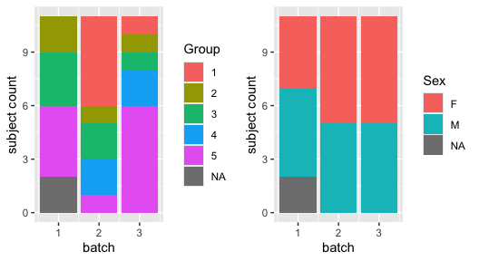

```r
bc$get_samples()
```

| batch | location | SubjectID | Group | Sex |
| --- | --- | --- | --- | --- |
| 1 | 1 | NA | NA | NA |
| 1 | 2 | P32 | 5 | M |
| 1 | 3 | P10 | 3 | F |
| ... | ... | ... | ... | ... |
| 3 | 9 | P31 | 3 | F |
| 3 | 10 | P33 | 5 | M |
| 3 | 11 | P24 | 5 | F |

## Optimization

- Assign 31 samples to 3 equally sized batches
- Balance by:
  - treatment group (higher priority)
  - sex (lower priority)

```r
bc <- optimize_design(
  bc,
  scoring = list(
    group = osat_score_generator(
      batch_vars = "batch",
      feature_vars = "Group"
    ),
    sex = osat_score_generator(
      batch_vars = "batch",
      feature_vars = "Sex"
    )
  ),
  n_shuffle = 1,
  acceptance_func =
    ~ accept_leftmost_improvement(..., tolerance = 0.01),
  max_iter = 150,
  quiet = TRUE
)
```

**Batch composition after optimization**

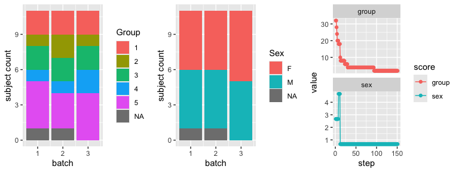

| batch | location | SubjectID | Group | Sex |
| --- | --- | --- | --- | --- |
| 1 | 1 | NA | NA | NA |
| 1 | 2 | P01 | 1 | F |
| 1 | 3 | P10 | 3 | F |
| ... | ... | ... | ... | ... |
| 3 | 9 | P29 | 5 | F |
| 3 | 10 | P33 | 5 | M |
| 3 | 11 | P12 | 3 | F |

# Plate layouts

## Continuous confounding

Assays are often performed in well plates (24, 96, 384)

Observed effects

- Edge effects (bad plate sealing)
- Gradients (non-equal temperature distribution)
- Row / column effects (pipetting issues)

Since plate effects often cannot be avoided, we aim to distribute sample groups of interest evenly across the plate and adjust for the effect computationally.

## Setup

- Assume previous batches are 24-well plates
- Within plate optimization & across plate blocking
- Balanced by:
  - treatment group (higher priority)
  - sex (lower priority)

```r
set.seed(4)

bc <- BatchContainer$new(
  dimensions = list("plate" = 3, "row" = 4, "col" = 6)
) |>
  assign_in_order(dat)
```

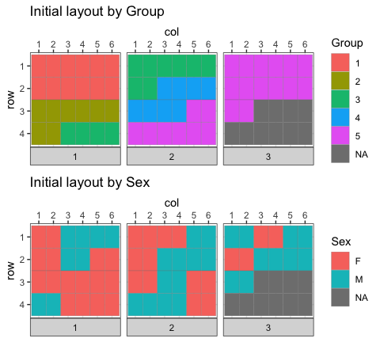

```r
plot_plate(bc,
  plate = plate, row = row, column = col,
  .color = Group, title = "Initial layout by Group"
)
plot_plate(bc,
  plate = plate, row = row, column = col,
  .color = Sex, title = "Initial layout by Sex"
)
```

## 2-step optimization

### Across plate optimization using osat score as before

```r
bc1 <- optimize_design(
  bc,
  scoring = list(
    group = osat_score_generator(
      batch_vars = "plate",
      feature_vars = "Group"
    ),
    sex = osat_score_generator(
      batch_vars = "plate",
      feature_vars = "Sex"
    )
  ),
  n_shuffle = 1,
  acceptance_func =
    ~ accept_leftmost_improvement(..., tolerance = 0.01),
  max_iter = 150,
  quiet = TRUE
)
```

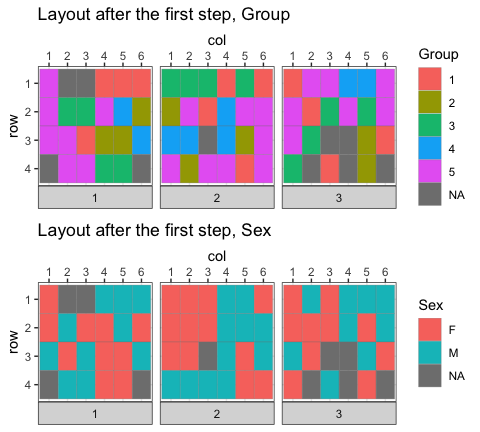

### Within plate optimization using distance based sample scoring function

```r
bc2 <- optimize_design(
  bc1,
  scoring = mk_plate_scoring_functions(
    bc1,
    plate = "plate", row = "row", column = "col",
    group = "Group"
  ),
  shuffle_proposal_func = shuffle_with_constraints(dst = plate == .src$plate),
  max_iter = 150,
  quiet = TRUE
)
```

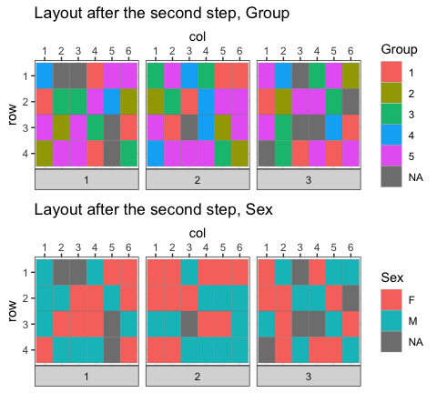

## 2-step optimization `multi_plate_layout()`

We are performing the same optimization as before, but using the `multi_plate_layout()` function to combine the two steps.

```r
bc <- optimize_multi_plate_design(
  bc,
  across_plates_variables = c("Group", "Sex"),
  within_plate_variables = c("Group"),
  plate = "plate", row = "row", column = "col",
  n_shuffle = 2,
  max_iter = 500 # 2000
)
```

```
#> 1 ... 2 ... 3 ...
```

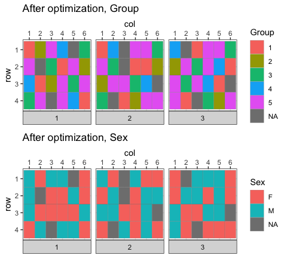

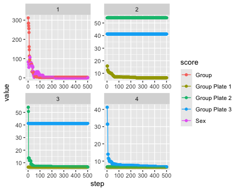

# Glimpse on more complex application

Goal:

- Assign 3 treatment conditions to 59 animals, representing 2 relevant strains
- Avoid confounding by sex, weight and age

Constraints:

- Cages host ideally 3 animals (preferably 2-5)
- Strain, Sex and Treatment must be homogeneous within a cage
- Don’t put males from different litters same cage; litter mixing is possible for females!
- Average weight and age composition comparable between treatment groups and cages
- Avoid animals with identical ear markings in same cage (if possible)
- Treatment distribution across animal subgroups (if specified) has to be respected

see vignette `invivo_study_design` for the full story.

# Conclusion

- designit aims to be general and adaptable
  - One framework to address simple batching as well as complex multi-step procedures
  - Easy add-ons: custom scoring-functions, acceptance-criteria and shuffling-procedures can be passed to optimize_design by the user
- Includes functions and vignettes for frequently used layouts such as plates.

**Acknowledgements**

- Martha Serrano
- Sabine Wilson
- David Jitao Zhang
- Fabian Birzele
- PMDA group for feedback?

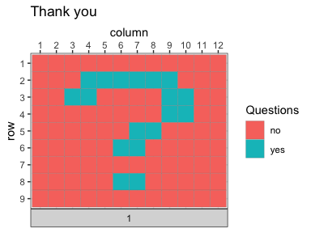